# Assingment 10B-CodeBase

Nobel Prize

Author

Mubin Ejaz

# Approach:

I’d first make just a simple call to API to make sure I can connect.  
I chose the 4 questions I’d want to be answered.

```r
library(httr2)
library(tidyverse)
library(DT)

# Getting Nobel laureate data
get_page <- function(offset) {
  request("https://api.nobelprize.org/2.1/laureates") %>%
    req_url_query(
      limit = 1000,
      offset = offset,
      format = "json"
    ) %>%
    req_perform() %>%
    resp_body_json()
}

# Downloading all pages
laureates <- list()
offset <- 0

repeat {
  data <- get_page(offset)
  page <- data$laureates

  if (length(page) == 0) break

  laureates <- append(laureates, page)

  if (length(page) < 1000) break

  offset <- offset + 1000
}

length(laureates)
```

```
[1] 1028
```

- Question 1:  
  ORIGINAL Question:  
  What is the basic criteria for choosing the nominees?

**The change:**  
One important distinction: the Nobel API publishes laureates and award motivations, but it does not publish current nominee lists or confidential nomination evaluations. Those records are kept secret for 50 years.

So:

- Q1 becomes: What reasons are given for awarding Nobel Prizes?

```r
# Helper function to get information from nested JSON
get_value <- function(x, ...) {
  value <- purrr::pluck(x, ..., .default = NA_character_)
  as.character(value[[1]])
}

# Getting the laureate's name
get_name <- function(x) {
  name <- get_value(x, "fullName", "en")

  if (is.na(name)) {
    name <- get_value(x, "orgName", "en")
  }

  name
}

# Getting birthplace country
get_country <- function(x) {
  country <- get_value(x, "birth", "place", "countryNow", "en")

  if (is.na(country)) {
    country <- get_value(x, "birth", "place", "country", "en")
  }

  country
}

# Creating a table of laureates
laureates_df <- tibble(
  id = map_chr(laureates, ~ get_value(.x, "id")),
  name = map_chr(laureates, get_name),
  gender = map_chr(laureates, ~ get_value(.x, "gender")),
  birth_country = map_chr(laureates, get_country),
  birth_date = map_chr(laureates, ~ get_value(.x, "birth", "date")),
  death_date = map_chr(laureates, ~ get_value(.x, "death", "date")),
  prizes = map(laureates, ~ purrr::pluck(.x, "nobelPrizes", .default = list()))
)

# Creating one row per laureate and prize
prize_df <- laureates_df %>%
  unnest_longer(prizes, values_to = "prize") %>%
  mutate(
    award_year = map_int(
      prize, ~ as.integer(get_value(.x, "awardYear"))
    ),
    category = map_chr(
      prize, ~ get_value(.x, "category", "en")
    ),
    motivation = map_chr(
      prize, ~ get_value(.x, "motivation", "en")
    ),
    date_awarded = map_chr(
      prize, ~ get_value(.x, "dateAwarded")
    ),
    affiliations = map(
      prize,
      ~ purrr::pluck(.x, "affiliations", .default = list())
    )
  )
```

```r
#QUESTION 1


# Showing the laureate, category, year and reason for the award

motivation_table <- prize_df %>%
  filter(!is.na(motivation), motivation != "") %>%
  select(
    AwardYear = award_year,
    Category = category,
    Laureate = name,
    Motivation = motivation
  ) %>%
  distinct() %>%
  arrange(desc(AwardYear))

head(motivation_table)
```

```
# A tibble: 6 × 4
  AwardYear Category               Laureate        Motivation
      <int> <chr>                  <chr>           <chr>
1      2026 Literature             Anne Carson     for her bold and inventive o…
2      2026 Physics                Francis Halzen  for decisive contributions t…
3      2026 Physiology or Medicine Georg Nagel     for their discoveries concer…
4      2026 Chemistry              Henri B. Kagan  for the discovery of non-lin…
5      2026 Physiology or Medicine Karl Deisseroth for their discoveries concer…
6      2026 Chemistry              Kenso Soai      for the discovery of non-lin…
```

The data returned doesn’t really answer my question. My question was actually answered by my online research/browsing. Every September, thousands of individuals, such as university professors, scientists, previous laureates, and members of national assemblies are invited to submit candidate names.

• Committee Review: Submitted candidates are handed over to dedicated Nobel Committees (comprising 5 to 10 members for each prize, or a 5-member committee appointed by the Norwegian Parliament for the Peace Prize). • Expert Consultation: Committees review the records, consult international experts, and commission detailed evaluation reports to narrow down the pool of candidates. • Iterative Deliberation: The committees discuss the shortlisted candidates thoroughly through the spring and summer.

3. Final Vote and Announcement (October)

• The Vote: Between August and September, the respective prize-awarding institutions (such as the Royal Swedish Academy of Sciences or the Norwegian Nobel Committee) take a final vote—usually by majority—to select the new laureates. • The Announcement: In the first week of October, the winners are officially announced globally.

- **Question 2:**  
  Does every category ends up with a winner every year  
  My approach is to check years in which a category had no winners

```r
# Finding the first and latest year for each category
latest_year <- max(prize_df$award_year, na.rm = TRUE)

category_years <- prize_df %>%
  group_by(category) %>%
  summarise(first_year = min(award_year), .groups = "drop") %>%
  mutate(
    award_year = map(first_year, ~ seq(.x, latest_year))
  ) %>%
  unnest(award_year)

# Finding category/year combinations without a laureate
missing_awards <- category_years %>%
  anti_join(
    prize_df %>% distinct(category, award_year),
    by = c("category", "award_year")
  )

# Counting years without awards by category
missing_awards %>%
  count(category, name = "years_without_award")
```

```
# A tibble: 5 × 2
  category               years_without_award
  <chr>                                <int>
1 Chemistry                                8
2 Literature                               7
3 Peace                                   19
4 Physics                                  6
5 Physiology or Medicine                   9
```

The results actually show the years corresponding category did not get award

- **Question 3:**  
  Does Nobel Prize laureates data seem to be politically motivated at all?  
  **The Change due to data limitations:**  
  Q3 becomes: How many Peace Prize recipients are individuals versus organizations? The data cannot establish political motivation by itself.

  Instead of trying to prove political motivation, I’ll compare the number of individual and organizational recipients of the Peace Prize.

  peace_results
  ```

  ```
  # A tibble: 2 × 2
    recipient_type     n
    <chr>          <int>
  1 Individual       113
  2 Unknown           31
  ```

  The table again doesn’t answer the question. I plotted the country laureatte’s were affiliated from vs # numbers of awards that country got.

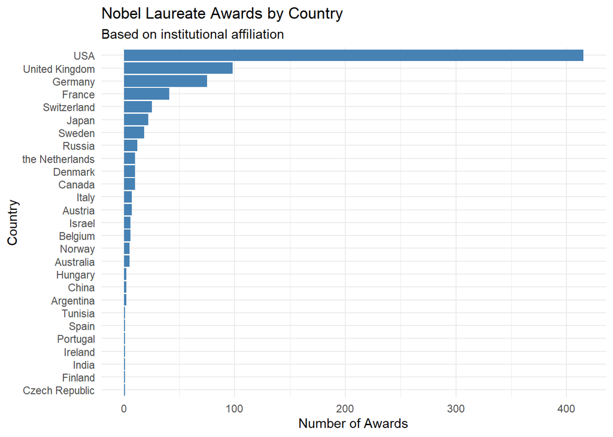

```r
# Counting Nobel awards by the laureate's birth country

country_awards <- prize_df %>%
  filter(!is.na(birth_country)) %>%
  distinct(id, award_year, category, birth_country) %>%
  count(birth_country, sort = TRUE, name = "Total_Awards")


country_awards <- prize_df %>%
  select(id, award_year, category, affiliations) %>%
  unnest_longer(affiliations, values_to = "affiliation") %>%
  mutate(
    country = map_chr(affiliation, function(x) {
      country <- x$countryNow$en

      if (is.null(country)) {
        country <- x$country$en
      }

      if (is.null(country)) NA_character_ else country
    })
  ) %>%
  filter(!is.na(country), country != "") %>%
  distinct(id, award_year, category, country) %>%
  count(country, sort = TRUE, name = "Total_Awards")

# Plotting Nobel laureate awards by country

ggplot(
  country_awards,
  aes(
    x = reorder(country, Total_Awards),
    y = Total_Awards
  )
) +
  geom_col(fill = "steelblue") +
  coord_flip() +
  labs(
    title = "Nobel Laureate Awards by Country",
    subtitle = "Based on institutional affiliation",
    x = "Country",
    y = "Number of Awards"
  ) +
  theme_minimal()
```

So, in my opinion, nobel prize organization doesn’t seem to be politically motivated. The Nobel organization is based/from Sweeden and Norway but the most awards are given to The USA Laureates.  
Infact, Swedan and Noaway seem to be below many.

- **Question 4:**  
  Can peaple that have passed away get nobel prize?  
  I’ll compare the laureate’s death date with the date the prize was announced.

```r
posthumous_results <- prize_df %>%
  mutate(
    death_date = as.Date(death_date),
    date_awarded = as.Date(date_awarded),
    death_year = as.integer(format(death_date, "%Y")),

    died_before_announcement = case_when(
      !is.na(death_date) & !is.na(date_awarded) ~
        death_date < date_awarded,

      !is.na(death_year) ~ death_year < award_year,

      TRUE ~ FALSE
    )
  ) %>%
  filter(died_before_announcement) %>%
  distinct(
    name, category, award_year,
    death_date, date_awarded
  ) %>%
  arrange(award_year)

posthumous_results
```

```
# A tibble: 3 × 5
  name                               category award_year death_date date_awarded
  <chr>                              <chr>         <int> <date>     <date>
1 Erik Axel Karlfeldt                Literat…       1931 1931-04-08 1931-11-08
2 Dag Hjalmar Agne Carl Hammarskjöld Peace          1961 1961-09-18 1961-10-23
3 Ralph M. Steinman                  Physiol…       2011 2011-09-30 2011-10-03
```

So Yes, it is given to people that have passed away.